# STAT 511: HW #4

Rumil Legaspi

1 March 2021

## **Workspace Setup**

```r
library(nortest)
library(olsrr)
library(car)
library(lmtest)
library(MASS)
library(ggplot2)

setwd("C:/Users/RUMIL/Desktop/APU/STAT 511 - Millie Mao (Applied Regression Analysis)/Week 6/Hw 4")

gpa_data = read.table(file = "GPA.txt", header = FALSE, sep = "")

gpa_data_extended = read.table(file = "GPA_Extended.txt", header = FALSE, sep = "")

# #Adding headers
names(gpa_data) <- c("GPA", "ACT")
names(gpa_data_extended) <- c("GPA", "ACT", "IQ", "Rank")
# names(bank_data) <- c("", "")

#Defining dependent and independent vars
GPA = gpa_data$GPA #Y
ACT = gpa_data$ACT #X1
IQ = gpa_data_extended$IQ #X2
RANK = gpa_data_extended$Rank #X3

gpa_lm = lm(GPA ~ ACT, data = gpa_data)
summary(gpa_lm)
```

```
Call:
lm(formula = GPA ~ ACT, data = gpa_data)

Residuals:
     Min       1Q   Median       3Q      Max
-2.74004 -0.33827  0.04062  0.44064  1.22737

Coefficients:
            Estimate Std. Error t value Pr(>|t|)
(Intercept)  2.11405    0.32089   6.588  1.3e-09 ***
ACT          0.03883    0.01277   3.040  0.00292 **
---
Signif. codes:  0 ‘***’ 0.001 ‘**’ 0.01 ‘*’ 0.05 ‘.’ 0.1 ‘ ’ 1

Residual standard error: 0.6231 on 118 degrees of freedom
Multiple R-squared:  0.07262,   Adjusted R-squared:  0.06476
F-statistic:  9.24 on 1 and 118 DF,  p-value: 0.002917
```

*Refer to the GPA problem (GPA.txt) for Questions 1-3*

# **1. Diagnostic plots:**

## **(a). Plot the regression residuals against the predicted values of the 𝑌 variable (residuals on the vertical axis). Check the linearity assumption visually.**

```r
plot(gpa_lm$fitted.values, gpa_lm$residuals)
```

[output not shown]

## **(b). Draw the boxplot, histogram, and normal probability plot of the regression residuals. Check the normality assumption visually.**

```r
#boxplot
boxplot(gpa_lm$residuals)

#histogram
hist(gpa_lm$residuals)

#Plotting specifically for QQ Plot
plot(gpa_lm, c(2))
```

[output not shown]

## **(c). Plot the regression residuals against the 𝑋 variable (residuals on the vertical axis). Check the equal variance assumption visually.**

```r
plot(gpa_data$ACT, gpa_lm$residuals)
```

[output not shown]

# **2. Diagnostic Tests:**

## **(a). Use normality tests to check the normality assumption and draw a conclusion.**

### Stating our Hypothesis

**Null Hypothesis**: ${H_0}$: The data **is** from a normal distribution

**Alternative Hypothesis**: ${H_1}$: The data is **NOT** from a normal distribution

### Testing our Hypothesis

**To test these we can use several normality tests using…**

- Shapiro-Wilk normality test
- Shapiro-Francia normality test
- Anderson-Darling normality test

```r
#Shapiro-Wilk normality test
shapiro.test(gpa_lm$residuals)

#Shapiro-Francia normality test
nortest::sf.test(gpa_lm$residuals)

#Anderson-Darling normality test
nortest::ad.test(gpa_lm$residuals)
```

[output not shown]

## **(b). Use Modified Levene Test and Breusch-Pagan Test to check the equal variance assumption and draw a conclusion.**

## Testing Equal Variance Assumptions

### Stating our Hypothesis

**Null Hypothesis**: ${H_0}$: The variances in the data **is** equal **Alternative Hypothesis**: ${H_1}$: The variances in the data are **NOT** equal

### Testing our Hypothesis Using Breusch-Pagan test

```r
#Conducting Levene Test splitting into two groups

#obtaining median of X to use as a threshold
gpa_median = median(gpa_data$ACT)
#ifelse: spliting X into 2 groups
  #one group x < gpa_median, another with x >= gpa_median
  #ifelse( "if this equation is true", "then do this", "else do this")
gpa_group = ifelse(gpa_data$ACT < gpa_median,
                   "Group1",
                   "Group2")

#Levene "Modified" test using median (default in R)
leveneTest(gpa_lm$residuals, gpa_group)

#bf.test(infection_lm, data = SENIC)

lmtest::bptest(gpa_lm, studentize = FALSE)
```

[output not shown]

## **(c). Conduct a lack-of-fit test for the regression model and conclude on the model fitness.**

### Stating our Hypothesis

**Null Hypothesis**: ${H_0}$: The regression line **IS adequate** in describing the relationship between ACT and GPA

**Alternative Hypothesis**: ${H_1}$: The regression line is **NOT adequate** in describing the relationship between ACT and GPA

### Testing our Hypothesis by Conducting our Lack of Fit Test (F Test)

```r
#Lack of Fit Test
ols_pure_error_anova(gpa_lm)
```

[output not shown]

# **3. Remediation:**

## **(a). Use Box-Cox method to find the best transformation of 𝑌 based on a range of 𝜆 ∈ [−3, 3], i.e., what is an approximate value of the optimal𝜆in 𝑌𝜆?**

```r
#Applying Box-Cox Method
MASS::boxcox(gpa_lm, lambda = seq(-3, 3, by = 0.1), plotit = FALSE)
MASS::boxcox(gpa_lm, lambda = seq(-3, 3, by = 0.1), plotit = TRUE)
```

[output not shown]

## **(b). Plot a smooth curve that best fits the dataset using LOESS method. Is the fitted smooth curve close to linear?**

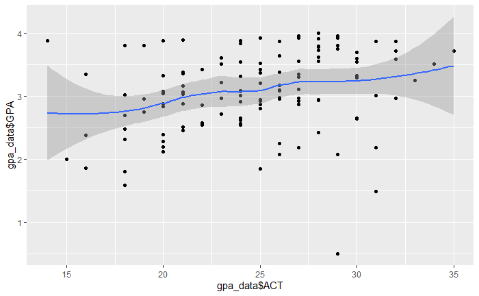

```r
#LOESS scatterplot and smoothed curve
smoothplot = qplot(gpa_data$ACT, gpa_data$GPA, geom=c("point", "smooth"))
smoothplot
```

***The fitted smooth curve is somewhat linear although the fit it is not a good fit.

# **4. Check for Omitted Predictors**

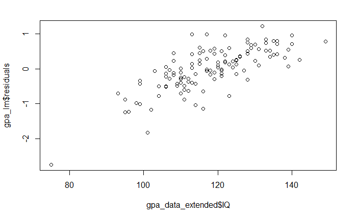

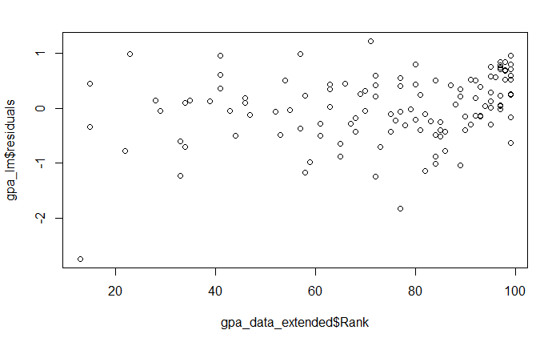

Based on the outputs, there is a visible pattern when plotting the residuals of our GPA-ACT linear regression model against potentially omitted variable, IQ ($X_{2}$). As for Rank it the plots on the graph seem somewhat scattered but more concentration the higher the rank gets.